# Analysis

Henrique

```r
Spec <- readxl::read_xls("~/Documents/NYFED/Spec_US_example.xls")

Spec
```

| Model | SeriesID | SeriesName | Frequency | Block1-Global | Block2-Soft | Block3-Real | Block4-Labor | Transformation | Units | Category |
| --- | --- | --- | --- | --- | --- | --- | --- | --- | --- | --- |
| 1 | PAYEMS | Payroll Employment | m | 1 | 0 | 0 | 1 | chg | Thousands of Persons | Labor |
| 1 | JTSJOL | Job Openings | m | 1 | 0 | 0 | 1 | chg | Thousands | Labor |
| 1 | GDPC1 | Real Gross Domestic Product | q | 1 | 0 | 1 | 0 | pca | Chained $, Billions | National Accounts |
| 1 | CPIAUCSL | Consumer Price Index | m | 1 | 0 | 0 | 0 | pch | Index | Prices |
| 1 | DGORDER | Durable Goods Orders | m | 1 | 0 | 1 | 0 | pch | $, Millions | Manufacturing |
| 0 | HSN1F | New Home Sales | m | 1 | 0 | 1 | 0 | pch | Thousands | Housing and Construction |
| 1 | RSAFS | Retail Sales | m | 1 | 0 | 1 | 0 | pch | $, Millions | Retail and Consumption |
| 1 | UNRATE | Unemployment Rate | m | 1 | 0 | 0 | 1 | chg | % | Labor |
| 1 | HOUST | Housing Starts | m | 1 | 0 | 1 | 0 | pch | Thousands of Units | Housing and Construction |
| 1 | INDPRO | Industrial Production | m | 1 | 0 | 1 | 0 | pch | Index | Manufacturing |

[output cut: 19 more lines]

```r
vintage = '2016-06-29.xls';

Z <-
readxl::read_xls(paste0(path_data, "/", vintage)) %>%
  mutate_at(vars("Date"), as.Date)

Z
```

| Date | PAYEMS | JTSJOL | CPIAUCSL | DGORDER | HSN1F | RSAFS | UNRATE | HOUST | INDPRO | PPIFIS | DSPIC96 | BOPTEXP | BOPTIMP | WHLSLRIMSA | TTLCONS | IR | CPILFESL | PCEPILFE | PCEPI | PERMIT | TCU | BUSINV | IQ | GACDISA066MSFRBNY | PCEC96 | GACDFSA066MSFRBPHI | GDPC1 | ULCNFB | A261RX1Q020SBEA |
| --- | --- | --- | --- | --- | --- | --- | --- | --- | --- | --- | --- | --- | --- | --- | --- | --- | --- | --- | --- | --- | --- | --- | --- | --- | --- | --- | --- | --- | --- |
| 1985-01-01 | 96373 | NA | 105.700 | NA | 645 | NA | 7.3 | 1711 | 56.6447 | NA | 5433.6 | NA | NA | NA | NA | NA | 107.100 | 55.854 | 55.732 | 1660 | 79.9 | NA | NA | NA | NA | 5.5 | NA | NA | NA |
| 1985-02-01 | 96497 | NA | 106.300 | NA | 682 | NA | 7.2 | 1632 | 56.8492 | NA | 5384.1 | NA | NA | NA | NA | NA | 107.700 | 56.153 | 55.998 | 1662 | 80.0 | NA | NA | NA | NA | 10.9 | NA | NA | NA |
| 1985-03-01 | 96843 | NA | 106.800 | NA | 671 | NA | 7.2 | 1800 | 56.9349 | NA | 5358.6 | NA | NA | NA | NA | 75.5 | 108.100 | 56.358 | 56.224 | 1727 | 79.9 | NA | 84.0 | NA | NA | 31.0 | 7469.5 | 65.636 | 7407.5 |
| 1985-04-01 | 97039 | NA | 107.000 | NA | 620 | NA | 7.3 | 1821 | 56.7821 | NA | 5450.3 | NA | NA | NA | NA | NA | 108.400 | 56.431 | 56.310 | 1664 | 79.5 | NA | NA | NA | NA | 10.0 | NA | NA | NA |
| 1985-05-01 | 97313 | NA | 107.200 | NA | 678 | NA | 7.2 | 1680 | 56.8643 | NA | 5578.0 | NA | NA | NA | NA | NA | 108.800 | 56.633 | 56.450 | 1709 | 79.4 | NA | NA | NA | NA | 8.0 | NA | NA | NA |
| 1985-06-01 | 97459 | NA | 107.500 | NA | 722 | NA | 7.4 | 1676 | 56.9021 | NA | 5459.2 | NA | NA | NA | NA | 75.8 | 109.100 | 56.827 | 56.609 | 1716 | 79.3 | NA | 84.4 | NA | NA | -2.4 | 7537.9 | 66.033 | 7461.5 |
| 1985-07-01 | 97649 | NA | 107.700 | NA | 766 | NA | 7.4 | 1684 | 56.5347 | NA | 5472.0 | NA | NA | NA | NA | NA | 109.400 | 56.995 | 56.749 | 1697 | 78.6 | NA | NA | NA | NA | 11.5 | NA | NA | NA |
| 1985-08-01 | 97842 | NA | 107.900 | NA | 726 | NA | 7.1 | 1743 | 56.7647 | NA | 5468.0 | NA | NA | NA | NA | NA | 109.800 | 57.274 | 56.938 | 1808 | 78.7 | NA | NA | NA | NA | 6.9 | NA | NA | NA |
| 1985-09-01 | 98045 | NA | 108.100 | NA | 678 | NA | 7.1 | 1676 | 57.0097 | NA | 5492.3 | NA | NA | NA | NA | 76.0 | 110.000 | 57.390 | 57.032 | 1916 | 78.9 | NA | 83.7 | NA | NA | 2.3 | 7655.2 | 66.174 | 7552.9 |
| 1985-10-01 | 98233 | NA | 108.500 | NA | 655 | NA | 7.1 | 1834 | 56.7733 | NA | 5520.8 | NA | NA | NA | NA | NA | 110.500 | 57.479 | 57.124 | 1743 | 78.5 | NA | NA | NA | NA | 6.2 | NA | NA | NA |

[output cut: 368 more lines]

Não há problema em ter redundância na hora de escolher as séries ?!?!?

- PAYEMS = Pay roll employment (saldo do vinculo empregaticio)
- JTSJOL = Admissoes em empregos de carteira assinada (vagas abertas)
- CPIAUCSL = inflation
- DGORDER = pedidos de bens duraveis
- HSN1F = New home sales
- RSAF = retail sales
- UNRATE = Taxa de desemprego
- HOUST = housing starts (inicio de construção de casas )
- INDPRO = produção industrial
- PPIFIS = indice de preços ao produtor (quanto variam os custos de insumos)
- DSPIC96 = personal income (renda)
- BOPTEXP = Exportação
- BOPTIMP = IMportação
- WHL… = Estoque de produtos (geral)
- TTLCONS = Gasto com construção
- IR = Indice de preço importado (sabe preço de quanto importou e quantidade = criar indice)
- CPILFESL = Inflação sem coisas mais volateis
- PCEPILFE = Deflator core do PIB (indice de preço implicito do pib)
- PCEPI = Deflator headline do PIB
- PERMIT = permissões de novas construções imobiliarias
- TCU = capacidade de utilização da industria
- BUSINV = business in ventures (estoque das fabricas)
- IQ = indice de preço de exportação
- GACDISA066MSFRBNY = impar state manufacturing (indice tipo PMI – survey)
- PCEC96 = Gasto real com consumo (das pessoas mas não temos certezas…. pode ter governo)
- GACDFSA066MSFRBPHI = survey especifico de filadelfia (vai entender…)
- GDPC1 = PIB
- ULCNFB = custo unitario do trabalho (medida de produtividade)
- A261RX1Q020SBEA = renda bruta domestica (soma de todos os salarios de todo mundo que trabalha / massa salarial)

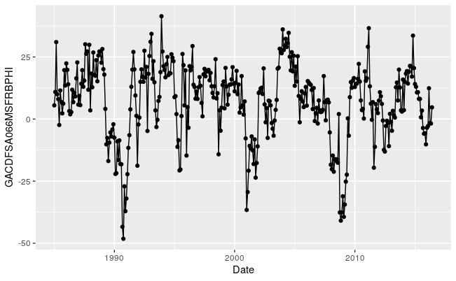

```r
Z %>%
#  filter(between(Date, as.Date("1986-01-01"), as.Date("2019-01-01"))) %>%
  ggplot(aes(x = Date, y = GACDFSA066MSFRBPHI)) +
  geom_point() +
  geom_line()
```

Let us define the following data transformations

```r
frequencies <-
Spec$Frequency %>%
  str_replace("q", "3") %>%
  str_replace("m", "1") %>%
  as.numeric()

lin <- function(z, freq) z

chg <- function(z, freq) {
  z - lag(z, freq)
}

ch1 <- function(z, freq) {
  chg(z, 12)
}

pch <- function(z, freq) {
  100 * ( z / lag(z, freq) - 1 )
}

pc1 <- function(z, freq) {
  pch(z, 12)
}

pca <- function(z, freq) {
  y <- z / lag(z, freq)
  100 * ( y ** (freq / 12) - 1 )
}
```

He filters his columns via the Model column in Specs. We deliberatly are **not** filtering because I want to see where it all goes wrong.

```r
# I do not need to consider all columns
remove_cols <-
Spec %>%
  filter(Model == 0) %>%
  select(SeriesID) %>%
  pull

X <-
pmap(
  list(Spec$Transformation, Spec$SeriesID, frequencies),
  ~ get(..1)( pull(Z[, ..2]), ..3 )
) %>%
  setNames(paste0("X_", Spec$SeriesID)) %>%
  bind_cols() %>%
  bind_cols(Date = Z$Date, .) #%>% select(- tidyselect::all_of(paste0("X_", remove_cols)))


X
```

| Date | X_PAYEMS | X_JTSJOL | X_GDPC1 | X_CPIAUCSL | X_DGORDER | X_HSN1F | X_RSAFS | X_UNRATE | X_HOUST | X_INDPRO | X_PPIFIS | X_DSPIC96 | X_BOPTEXP | X_BOPTIMP | X_WHLSLRIMSA | X_TTLCONS | X_IR | X_CPILFESL | X_PCEPILFE | X_PCEPI | X_PERMIT | X_TCU | X_BUSINV | X_ULCNFB | X_IQ | X_GACDISA066MSFRBNY | X_PCEC96 | X_A261RX1Q020SBEA | X_GACDFSA066MSFRBPHI |
| --- | --- | --- | --- | --- | --- | --- | --- | --- | --- | --- | --- | --- | --- | --- | --- | --- | --- | --- | --- | --- | --- | --- | --- | --- | --- | --- | --- | --- | --- |
| 1985-01-01 | NA | NA | NA | NA | NA | NA | NA | NA | NA | NA | NA | NA | NA | NA | NA | NA | NA | NA | NA | NA | NA | NA | NA | NA | NA | NA | NA | NA | 5.5 |
| 1985-02-01 | 124 | NA | NA | 0.56764428 | NA | 5.7364341 | NA | -0.1 | -4.61718293 | 0.361022302 | NA | -0.910998233 | NA | NA | NA | NA | NA | 0.56022409 | 0.535324238 | 0.477284146 | 2 | 0.1 | NA | NA | NA | NA | NA | NA | 10.9 |
| 1985-03-01 | 346 | NA | NA | 0.47036689 | NA | -1.6129032 | NA | 0.0 | 10.29411765 | 0.150749703 | NA | -0.473616760 | NA | NA | NA | NA | NA | 0.37140204 | 0.365073994 | 0.403585842 | 65 | -0.1 | NA | NA | NA | NA | NA | NA | 31.0 |
| 1985-04-01 | 196 | NA | NA | 0.18726592 | NA | -7.6005961 | NA | 0.1 | 1.16666667 | -0.268376690 | NA | 1.711267868 | NA | NA | NA | NA | NA | 0.27752081 | 0.129529082 | 0.152959590 | -63 | -0.4 | NA | NA | NA | NA | NA | NA | 10.0 |
| 1985-05-01 | 274 | NA | NA | 0.18691589 | NA | 9.3548387 | NA | -0.1 | -7.74299835 | 0.144763931 | NA | 2.342990294 | NA | NA | NA | NA | NA | 0.36900369 | 0.357959278 | 0.248623690 | 45 | -0.1 | NA | NA | NA | NA | NA | NA | 8.0 |
| 1985-06-01 | 146 | NA | 0.228149018 | 0.27985075 | NA | 6.4896755 | NA | 0.2 | -0.23809524 | 0.066474044 | NA | -2.129795626 | NA | NA | NA | NA | NA | 0.27573529 | 0.342556460 | 0.281665190 | 7 | -0.1 | NA | 0.150870975 | NA | NA | NA | 0.181751616 | -2.4 |
| 1985-07-01 | 190 | NA | NA | 0.18604651 | NA | 6.0941828 | NA | 0.0 | 0.47732697 | -0.645670371 | NA | 0.234466589 | NA | NA | NA | NA | NA | 0.27497709 | 0.295634118 | 0.247310498 | -19 | -0.7 | NA | NA | NA | NA | NA | NA | 11.5 |
| 1985-08-01 | 193 | NA | NA | 0.18570102 | NA | -5.2219321 | NA | -0.3 | 3.50356295 | 0.406829788 | NA | -0.073099415 | NA | NA | NA | NA | NA | 0.36563071 | 0.489516624 | 0.333045516 | 111 | 0.1 | NA | NA | NA | NA | NA | NA | 6.9 |
| 1985-09-01 | 203 | NA | 0.386784258 | 0.18535681 | NA | -6.6115702 | NA | 0.0 | -3.84394722 | 0.431606262 | NA | 0.444403804 | NA | NA | NA | NA | NA | 0.18214936 | 0.202535182 | 0.165091854 | 108 | 0.2 | NA | 0.053339708 | NA | NA | NA | 0.304841928 | 2.3 |
| 1985-10-01 | 188 | NA | NA | 0.37002775 | NA | -3.3923304 | NA | 0.0 | 9.42720764 | -0.414666276 | NA | 0.518908290 | NA | NA | NA | NA | NA | 0.45454545 | 0.155079282 | 0.161312947 | -173 | -0.4 | NA | NA | NA | NA | NA | NA | 6.2 |

[output cut: 368 more lines]

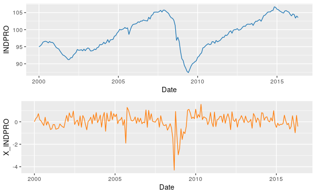

```r
p_indpro_raw <-
Z %>%
 filter(Date >= as.Date("2000-01-01")) %>%
 ggplot(aes(x = Date, y = INDPRO)) +
  geom_line(color = plotly_colors[1], na.rm = TRUE)


p_indpro_x <-
X %>%
 filter(Date >= as.Date("2000-01-01")) %>%
 ggplot(aes(x = Date, y = X_INDPRO)) +
  geom_line(color = plotly_colors[2], na.rm = TRUE)

#p <-
gridExtra::grid.arrange(grobs = list(p_indpro_raw, p_indpro_x), nrow = 2)
```

# DFM (this is it!)

```r
Blocks <-
Spec %>%
  select(contains("Block")) %>%
  select(-contains("Global"))

Blocks
```

| Block2-Soft | Block3-Real | Block4-Labor |
| --- | --- | --- |
| 0 | 0 | 1 |
| 0 | 0 | 1 |
| 0 | 1 | 0 |
| 0 | 0 | 0 |
| 0 | 1 | 0 |
| 0 | 1 | 0 |
| 0 | 1 | 0 |
| 0 | 0 | 1 |
| 0 | 1 | 0 |
| 0 | 1 | 0 |

[output cut: 19 more lines]

```r
nQ <-
Spec %>%
  filter(!SeriesID %in% remove_cols) %>%
  select(Frequency) %>%
  pull %>%
  str_count("q") %>%
  sum

nQ
```

```
[1] 2
```

```r
i_idio <- # -1 because we are dealing with dates.
c(rep(1, ncol(X) - nQ  - 1), rep(0, nQ))

R_mat = c(2, -1,  0,  0,  0,
          3,  0, -1,  0,  0,
          2,  0,  0, -1,  0,
          1,  0,  0,  0, -1 ) %>% matrix(. , nrow = 4, ncol = 5)

q = rep(0, 4)


X %>%
  mutate_at(vars(-Date), ~ (.x - mean(.x, na.rm = TRUE))/ sd(.x, na.rm = TRUE))
```

| Date | X_PAYEMS | X_JTSJOL | X_GDPC1 | X_CPIAUCSL | X_DGORDER | X_HSN1F | X_RSAFS | X_UNRATE | X_HOUST | X_INDPRO | X_PPIFIS | X_DSPIC96 | X_BOPTEXP | X_BOPTIMP | X_WHLSLRIMSA | X_TTLCONS | X_IR | X_CPILFESL | X_PCEPILFE | X_PCEPI | X_PERMIT | X_TCU | X_BUSINV | X_ULCNFB | X_IQ | X_GACDISA066MSFRBNY | X_PCEC96 | X_A261RX1Q020SBEA | X_GACDFSA066MSFRBPHI |
| --- | --- | --- | --- | --- | --- | --- | --- | --- | --- | --- | --- | --- | --- | --- | --- | --- | --- | --- | --- | --- | --- | --- | --- | --- | --- | --- | --- | --- | --- |
| 1985-01-01 | NA | NA | NA | NA | NA | NA | NA | NA | NA | NA | NA | NA | NA | NA | NA | NA | NA | NA | NA | NA | NA | NA | NA | NA | NA | NA | NA | NA | -0.097429231 |
| 1985-02-01 | -0.011775082 | NA | NA | 1.337260189 | NA | 0.8005558542 | NA | -0.59617632 | -0.646360418 | 0.321742408 | NA | -1.4238992484 | NA | NA | NA | NA | NA | 2.855695226 | 3.011382e+00 | 1.556904978 | 0.050002543 | 0.23593689 | NA | NA | NA | NA | NA | NA | 0.255619847 |
| 1985-03-01 | 1.083977037 | NA | NA | 0.965191945 | NA | -0.2621731916 | NA | 0.04428738 | 1.366951013 | -0.019017410 | NA | -0.8764905601 | NA | NA | NA | NA | NA | 1.258422520 | 1.556450e+00 | 1.168041547 | 0.978262924 | -0.18055264 | NA | NA | NA | NA | NA | NA | 1.569746971 |
| 1985-04-01 | 0.343603983 | NA | NA | -0.117617539 | NA | -1.1280056976 | NA | 0.68475108 | 0.134570156 | -0.698237782 | NA | 1.8580213092 | NA | NA | NA | NA | NA | 0.464267777 | -4.564802e-01 | -0.154368602 | -0.907726421 | -0.80528693 | NA | NA | NA | NA | NA | NA | 0.196778334 |
| 1985-05-01 | 0.728597971 | NA | NA | -0.118956339 | NA | 1.3237844794 | NA | -0.59617632 | -1.068405422 | -0.028717725 | NA | 2.6486591525 | NA | NA | NA | NA | NA | 1.238134511 | 1.495649e+00 | 0.350395666 | 0.683577089 | -0.18055264 | NA | NA | NA | NA | NA | NA | 0.066019417 |
| 1985-06-01 | 0.096812966 | NA | 0.45672393 | 0.236502516 | NA | 0.9094760855 | NA | 1.32521478 | -0.055099631 | -0.155591353 | NA | -2.9492960093 | NA | NA | NA | NA | NA | 0.449163808 | 1.364019e+00 | 0.524736602 | 0.123674002 | -0.18055264 | NA | 0.176108714 | NA | NA | NA | 0.100836624 | -0.613926956 |
| 1985-07-01 | 0.313989061 | NA | NA | -0.122281544 | NA | 0.8522870424 | NA | 0.04428738 | 0.041496082 | -1.309665644 | NA | 0.0097174788 | NA | NA | NA | NA | NA | 0.442750011 | 9.630277e-01 | 0.343466710 | -0.259417584 | -1.43002122 | NA | NA | NA | NA | NA | NA | 0.294847523 |
| 1985-08-01 | 0.328796522 | NA | NA | -0.123602981 | NA | -0.7840460698 | NA | -1.87710372 | 0.450095952 | 0.395976286 | NA | -0.3752194999 | NA | NA | NA | NA | NA | 1.209602016 | 2.619917e+00 | 0.795840940 | 1.656040345 | 0.23593689 | NA | NA | NA | NA | NA | NA | -0.005897988 |
| 1985-09-01 | 0.378154726 | NA | 1.52301400 | -0.124919520 | NA | -0.9849905550 | NA | 0.04428738 | -0.541958773 | 0.436128103 | NA | 0.2724662756 | NA | NA | NA | NA | NA | -0.342492975 | 1.674186e-01 | -0.090353644 | 1.611837470 | 0.44418165 | NA | -0.201720673 | NA | NA | NA | 0.848144433 | -0.306643499 |
| 1985-10-01 | 0.304117421 | NA | NA | 0.581413088 | NA | -0.5194819583 | NA | 0.04428738 | 1.249901543 | -0.935309150 | NA | 0.3657130302 | NA | NA | NA | NA | NA | 1.961744534 | -2.381321e-01 | -0.110292757 | -2.528498514 | -0.80528693 | NA | NA | NA | NA | NA | NA | -0.051663609 |

[output cut: 368 more lines]

We will deal with NAs in the following way:

```r
spline(v, X_f$X_PAYEMS[v])
```

[output not shown]

[output cut: 282 more lines]